# MLE&MAP 2

I am glad to receive the datasets from Mr.Matthews, although the dataset doesn’t contain the series after preprocessing. He should misunderstand my meaning of ‘adjusted’.

```r
rm(list = ls())
set.seed(9483)
```

```r
library(ggplot2)
library(ggfortify)
library(forecast)
library(tseries)
library(seasonal)
library(KFAS)
library(matrixStats)
```

```r
retailtrade <- read.csv('C:\\Users\\GuoLY\\Desktop\\StatCan\\retailtrade1.csv', header = FALSE)
retailtrade <- retailtrade[-1,] # I remove names of calsses here
head(retailtrade)
```

[output not shown]

```r
# extract the sum to do analysis
sum <- ts(as.numeric(gsub(',','',as.character(retailtrade[-1,2]))),
          start=c(2004, 1), frequency = 12)
sum_sa <- ts(as.numeric(gsub(',','',as.character(retailtrade[-1,3]))),
          start=c(2004, 1), frequency = 12)
# Note: use gsub(',', '', data) to remove the comma in our data
```

```r
auto.arima(sum)
```

```
Series: sum
ARIMA(2,0,3)(0,1,0)[12] with drift

Coefficients:
         ar1     ar2     ma1      ma2     ma3     drift
      0.1382  0.4378  0.2050  -0.0944  0.4289  123216.0
s.e.  0.1490  0.1464  0.1393   0.1245  0.0785   20578.1

sigma^2 estimated as 8.678e+11:  log likelihood=-2651.2
AIC=5316.39   AICc=5317.06   BIC=5338.54
```

```r
mod_sum_seats <- seas(sum)
summary(mod_sum_seats)
```

```
Call:
seas(x = sum)

Coefficients:
                   Estimate Std. Error z value Pr(>|z|)
Mon               -0.008773   0.001355  -6.473 9.61e-11 ***
Tue                0.004112   0.001351   3.044  0.00234 **
Wed                0.002132   0.001347   1.582  0.11355
Thu                0.003998   0.001351   2.959  0.00309 **
Fri                0.007000   0.001354   5.171 2.32e-07 ***
Sat                0.005974   0.001380   4.330 1.49e-05 ***
Easter[1]         -0.006157   0.002437  -2.527  0.01152 *
AO2008.Nov        -0.043471   0.009987  -4.353 1.34e-05 ***
LS2008.Dec        -0.087107   0.010708  -8.135 4.12e-16 ***
AO2015.Jan        -0.036355   0.008275  -4.393 1.12e-05 ***
MA-Nonseasonal-01  0.393795   0.069659   5.653 1.57e-08 ***
MA-Seasonal-12     0.326002   0.072542   4.494 6.99e-06 ***
---
Signif. codes:  0 ‘***’ 0.001 ‘**’ 0.01 ‘*’ 0.05 ‘.’ 0.1 ‘ ’ 1

SEATS adj.  ARIMA: (0 1 1)(0 1 1)  Obs.: 187  Transform: log
AICc:  5067, BIC:  5106  QS (no seasonality in final):    0
Box-Ljung (no autocorr.): 28.88   Shapiro (normality): 0.9916
Messages generated by X-13:
Notes:
- Unable to test LS2008.Nov due to regression matrix singularity.
```

```r
mod_sum_x11 <- seas(sum, x11='')
summary(mod_sum_x11)
```

```
Call:
seas(x = sum, x11 = "")

Coefficients:
                   Estimate Std. Error z value Pr(>|z|)
Mon               -0.008773   0.001355  -6.473 9.61e-11 ***
Tue                0.004112   0.001351   3.044  0.00234 **
Wed                0.002132   0.001347   1.582  0.11355
Thu                0.003998   0.001351   2.959  0.00309 **
Fri                0.007000   0.001354   5.171 2.32e-07 ***
Sat                0.005974   0.001380   4.330 1.49e-05 ***
Easter[1]         -0.006157   0.002437  -2.527  0.01152 *
AO2008.Nov        -0.043471   0.009987  -4.353 1.34e-05 ***
LS2008.Dec        -0.087107   0.010708  -8.135 4.12e-16 ***
AO2015.Jan        -0.036355   0.008275  -4.393 1.12e-05 ***
MA-Nonseasonal-01  0.393795   0.069659   5.653 1.57e-08 ***
MA-Seasonal-12     0.326002   0.072542   4.494 6.99e-06 ***
---
Signif. codes:  0 ‘***’ 0.001 ‘**’ 0.01 ‘*’ 0.05 ‘.’ 0.1 ‘ ’ 1

X11 adj.  ARIMA: (0 1 1)(0 1 1)  Obs.: 187  Transform: log
AICc:  5067, BIC:  5106  QS (no seasonality in final):    0
Box-Ljung (no autocorr.): 28.88   Shapiro (normality): 0.9916
Messages generated by X-13:
Notes:
- Unable to test LS2008.Nov due to regression matrix singularity.
```

[figure not shown]

[figure not shown]

**Note:** We have a problem here… our model is multiplicative but the state-space model we used so far is addictive. Therefore, we need to do some transformation when computing.

## Transformation under multiplicative cases

$$Y_t = T_t*S_t*\epsilon_t$$

As we can see above, if we use the result from the *seasonal* and then compute the product, it is quite close to the initial series(cause we may remove some outliers or calendar effect at the beginning). **But** if we want to apply it to formal fomular and calculate *MLE*, we need to take logarithm of it. Therefore, we have:
$$logY_t = logT_t + logS_t + log\epsilon_t$$

I realize that this part is a little complex. I can’t figure out this model tonight.

**TO BE CONTINUED**

## Unemployment Case

```r
data_em <- unemp

mod_em_seats <- seas(data_em)


em_ssm <- SSModel(data_em ~ SSMtrend(1, Q = list(1)) +
                        SSMseasonal(12,Q=1, sea.type = "dummy"), H=1)
mod_em_ssm <- KFS(em_ssm)
```

```r
# define the expression of MLE
var_y_hat <- function(Trend, Season, Obs){
  sum((Obs-Trend-Season)^2)/length(Obs)
}

var_T_hat <- function(Trend){
  sum((Trend[2:length(Trend)]-Trend[1:(length(Trend)-1)])^2)/(length(Trend)-1)
}

var_S_hat <- function(Season) {
  a = 0
  for(t in 12:length(Season)){
    a = a + sum(Season[(t-11):t])^2
  }
  return(a/(length(Season)-11))
}

var_seasadj <- function(seats,ssm){
  seasadj_ssm <- data_em - rowSums(coef(ssm, states = "seasonal"))
  data <- series(seats, "s11") - seasadj_ssm
  return(var(data))
}
```

```r
# this chunk is to compute the mle from seas
season_em_seats <- series(mod_em_seats, 's10')
trend_em_seats <- series(mod_em_seats, 's12')
irregular_em_seats <- series(mod_em_seats, 's13')

sigma1_em_seats <- var_y_hat(Trend = trend_em_seats, Season = season_em_seats, Obs = data_em)
sigma2_em_seats <- var_T_hat(Trend = trend_em_seats)
sigma3_em_seats <- var_S_hat(Season = season_em_seats)

sigma1_em_seats
```

```
[1] 5842.922
```

```r
sigma2_em_seats
```

```
[1] 26898.92
```

```r
sigma3_em_seats
```

```
[1] 178.9115
```

```r
# we apply the mle to kalman filter to check the result
em_ssm_mle <- SSModel(data_em ~ SSMtrend(1, Q=list(sigma2_em_seats)) +
                              SSMseasonal(12, sea.type="dummy", Q=sigma3_em_seats),
                            H = sigma1_em_seats)
mod_em_ssm_mle <- KFS(em_ssm_mle)

trend_em_ssm_mle <- coef(mod_em_ssm_mle, states = 'trend')
season_em_ssm_mle <- rowSums(coef(mod_em_ssm_mle, states = 'seasonal'))
```

```r
plot(trend_em_seats, ylab='')
par(new=TRUE)
```

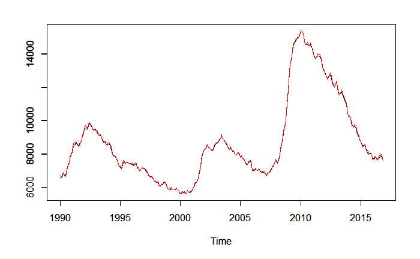

```r
plot(trend_em_ssm_mle, ylab='', col=2)
```

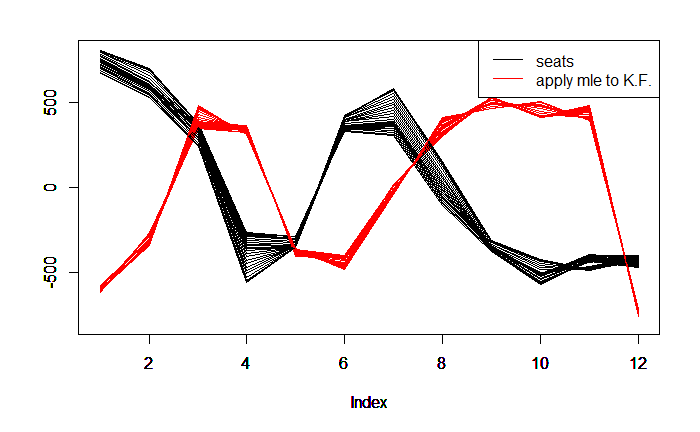

```r
# seasonal
for(i in 1:27){
  plot(season_em_seats[(1+(i-1)*12):(i*12)], ylab='',
       type='l', ylim = c(-800,800))
  par(new=TRUE)
  plot(season_em_ssm_mle[(1+(i-1)*12):(i*12)], ylab='', col=2,
       type='l', ylim = c(-800,800))
  par(new=TRUE)
}
legend('topright', c('seats','apply mle to K.F.'), col=c(1,2), lty=c(1,1))
```

I don’t know why these two seasonal components are different. I didn’t use the algorithm above, so it is not the problem of my alg.

**Comments after meeting 20191002** 我好像理解错了问题。MLE产生的结果不对是没错的，如果MLE产生的结果和TRAMO-SEATS的结果一样的话，也就不需要我来研究怎么解决这个问题了。所以如何促使从‘MLE’得到的结果类似于results from TRAMO-SEATS就是我要做的了。之所以‘MLE’加引号，是因为我们实际上要算MAP。和之前的算法类似，我们第一步还是用kalman filter计算$\{T_t\}\ \ \{S_t\}$,然后在给定某个先验分布的前提下，通过$\{T_t\}\ \ \{S_t\}$计算MAP值。